# Remote Work & Mental Health Project

## Build models Train-Test Split Predict Model Performance

# Setting up data for models

```r
# Filter dataset to only employees that work remote or hybrid for accurate predictive models
Hybrid_Remote_Data <- Remote %>%
  filter(Remote$Work_Location == "Hybrid" | Remote$Work_Location == "Remote")
```

```r
# Convert all character columns to factors
Hybrid_Remote_Data <- Hybrid_Remote_Data %>%
  mutate(across(where(is.character), as.factor))

# Check results
str(Hybrid_Remote_Data)
```

```
## 'data.frame':    3363 obs. of  20 variables:
##  $ Employee_ID                      : Factor w/ 3363 levels "EMP0001","EMP0002",..: 1 2 3 4 5 6 7 8 9 10 ...
##  $ Age                              : int  32 40 59 59 31 56 30 33 47 40 ...
##  $ Gender                           : Factor w/ 4 levels "Female","Male",..: 3 1 3 3 4 4 1 3 1 1 ...
##  $ Job_Role                         : Factor w/ 7 levels "Data Scientist",..: 3 1 7 6 6 1 3 7 4 4 ...
##  $ Industry                         : Factor w/ 7 levels "Consulting","Education",..: 4 5 2 5 5 4 5 3 1 1 ...
##  $ Years_of_Experience              : int  13 3 22 31 24 9 28 17 31 1 ...
##  $ Work_Location                    : Factor w/ 2 levels "Hybrid","Remote": 1 2 1 1 2 1 1 2 1 2 ...
##  $ Hours_Worked_Per_Week            : int  47 52 46 39 51 24 57 48 26 21 ...
##  $ Number_of_Virtual_Meetings       : int  7 4 11 3 7 4 6 3 12 7 ...
##  $ Work_Life_Balance_Rating         : int  2 1 5 4 3 2 1 3 4 2 ...
##  $ Stress_Level                     : Factor w/ 3 levels "High","Low","Medium": 3 3 3 1 2 1 2 1 3 1 ...
##  $ Mental_Health_Condition          : Factor w/ 4 levels "Anxiety","Burnout",..: 3 1 1 4 1 4 3 4 4 3 ...
##  $ Access_to_Mental_Health_Resources: Factor w/ 2 levels "No","Yes": 1 1 1 1 2 2 2 2 2 2 ...
##  $ Productivity_Change              : Factor w/ 3 levels "Decrease","Increase",..: 1 2 3 2 1 1 1 1 3 1 ...
##  $ Social_Isolation_Rating          : int  1 3 4 5 5 2 2 4 4 2 ...
##  $ Satisfaction_with_Remote_Work    : Factor w/ 3 levels "Neutral","Satisfied",..: 3 2 3 3 1 3 1 2 1 1 ...
##  $ Company_Support_for_Remote_Work  : int  1 2 5 1 3 4 1 2 3 1 ...
##  $ Physical_Activity                : Factor w/ 3 levels "Daily","None",..: 3 3 2 2 1 1 3 3 3 3 ...
##  $ Sleep_Quality                    : Factor w/ 3 levels "Average","Good",..: 2 2 3 1 3 3 3 1 3 2 ...
##  $ Region                           : Factor w/ 6 levels "Africa","Asia",..: 3 2 4 6 2 3 4 5 1 3 ...
```

```r
# Recode Stress_Level to be a binary variable where "Low" = 0 ,"Medium and High" = 1
Hybrid_Remote_Data <- Hybrid_Remote_Data %>%
  mutate(b_stress_level = ifelse(Stress_Level == "Low", 0, 1)) %>%
  select(-Stress_Level)
```

```r
# Remove original Stress-Level variable to avoid confusion with the new variable
Hybrid_Remote_Data$b_stress_level <- factor(Hybrid_Remote_Data$b_stress_level, levels = c(0, 1))
table(Hybrid_Remote_Data$b_stress_level)
```

```
##
##    0    1
## 1090 2273
```

```r
Hybrid_Remote_Data %>%
  group_by(b_stress_level) %>%
  summarise(
    count = n(),
    Percentage = (n() / nrow(Hybrid_Remote_Data)) * 100
  )
```

```
## # A tibble: 2 × 3
##   b_stress_level count Percentage
##   <fct>          <int>      <dbl>
## 1 0               1090       32.4
## 2 1               2273       67.6
```

```r
# Partition the data into train  and test set
set.seed(123)
trainIndex <- createDataPartition(Hybrid_Remote_Data$b_stress_level, p = .8, list = FALSE)
r_train <- Hybrid_Remote_Data[trainIndex, ]
r_test <- Hybrid_Remote_Data[-trainIndex, ]

# Check target variable distribution
table(r_train$b_stress_level)
```

```
##
##    0    1
##  872 1819
```

```r
prop.table(table(r_train$b_stress_level))
```

```
##
##         0         1
## 0.3240431 0.6759569
```

```r
table(r_test$b_stress_level)
```

```
##
##   0   1
## 218 454
```

```r
prop.table(table(r_test$b_stress_level))
```

```
##
##         0         1
## 0.3244048 0.6755952
```

```r
# Drop Employee_ID column before training and testing
r_train <- r_train %>%
  select(-Employee_ID)

r_test <- r_test %>%
  select(-Employee_ID)

# Verify the structure after dropping Employee_ID
str(r_train)
```

```
## 'data.frame':    2691 obs. of  19 variables:
##  $ Age                              : int  32 40 59 56 30 33 47 40 36 56 ...
##  $ Gender                           : Factor w/ 4 levels "Female","Male",..: 3 1 3 4 1 3 1 1 4 1 ...
##  $ Job_Role                         : Factor w/ 7 levels "Data Scientist",..: 3 1 6 1 3 7 4 4 5 6 ...
##  $ Industry                         : Factor w/ 7 levels "Consulting","Education",..: 4 5 5 4 5 3 1 1 7 4 ...
##  $ Years_of_Experience              : int  13 3 31 9 28 17 31 1 23 13 ...
##  $ Work_Location                    : Factor w/ 2 levels "Hybrid","Remote": 1 2 1 1 1 2 1 2 2 2 ...
##  $ Hours_Worked_Per_Week            : int  47 52 39 24 57 48 26 21 59 44 ...
##  $ Number_of_Virtual_Meetings       : int  7 4 3 4 6 3 12 7 11 11 ...
##  $ Work_Life_Balance_Rating         : int  2 1 4 2 1 3 4 2 3 4 ...
##  $ Mental_Health_Condition          : Factor w/ 4 levels "Anxiety","Burnout",..: 3 1 4 4 3 4 4 3 1 1 ...
##  $ Access_to_Mental_Health_Resources: Factor w/ 2 levels "No","Yes": 1 1 1 2 2 2 2 2 2 1 ...
##  $ Productivity_Change              : Factor w/ 3 levels "Decrease","Increase",..: 1 2 2 1 1 1 3 1 1 3 ...
##  $ Social_Isolation_Rating          : int  1 3 5 2 2 4 4 2 5 5 ...
##  $ Satisfaction_with_Remote_Work    : Factor w/ 3 levels "Neutral","Satisfied",..: 3 2 3 3 1 2 1 1 1 2 ...
##  $ Company_Support_for_Remote_Work  : int  1 2 1 4 1 2 3 1 3 4 ...
##  $ Physical_Activity                : Factor w/ 3 levels "Daily","None",..: 3 3 2 1 3 3 3 3 3 3 ...
##  $ Sleep_Quality                    : Factor w/ 3 levels "Average","Good",..: 2 2 1 3 3 1 3 2 1 1 ...
##  $ Region                           : Factor w/ 6 levels "Africa","Asia",..: 3 2 6 3 4 5 1 3 5 1 ...
##  $ b_stress_level                   : Factor w/ 2 levels "0","1": 2 2 2 2 1 2 2 2 2 1 ...
```

```r
str(r_test)
```

```
## 'data.frame':    672 obs. of  19 variables:
##  $ Age                              : int  59 31 51 49 36 46 32 26 27 56 ...
##  $ Gender                           : Factor w/ 4 levels "Female","Male",..: 3 4 3 3 2 4 2 4 2 2 ...
##  $ Job_Role                         : Factor w/ 7 levels "Data Scientist",..: 7 6 2 7 2 6 4 2 5 2 ...
##  $ Industry                         : Factor w/ 7 levels "Consulting","Education",..: 2 5 6 5 5 4 7 6 1 7 ...
##  $ Years_of_Experience              : int  22 24 5 30 24 28 24 31 21 9 ...
##  $ Work_Location                    : Factor w/ 2 levels "Hybrid","Remote": 1 2 1 2 1 1 2 2 1 1 ...
##  $ Hours_Worked_Per_Week            : int  46 51 45 36 22 57 42 51 21 42 ...
##  $ Number_of_Virtual_Meetings       : int  11 7 13 6 6 8 8 4 7 14 ...
##  $ Work_Life_Balance_Rating         : int  5 3 1 1 4 4 2 1 5 4 ...
##  $ Mental_Health_Condition          : Factor w/ 4 levels "Anxiety","Burnout",..: 1 1 1 1 3 4 2 4 2 4 ...
##  $ Access_to_Mental_Health_Resources: Factor w/ 2 levels "No","Yes": 1 2 1 1 1 2 1 1 1 2 ...
##  $ Productivity_Change              : Factor w/ 3 levels "Decrease","Increase",..: 3 1 1 3 3 3 3 1 3 1 ...
##  $ Social_Isolation_Rating          : int  4 5 2 3 1 1 2 2 4 2 ...
##  $ Satisfaction_with_Remote_Work    : Factor w/ 3 levels "Neutral","Satisfied",..: 3 1 2 2 3 1 1 3 3 3 ...
##  $ Company_Support_for_Remote_Work  : int  5 3 5 2 3 5 3 3 3 5 ...
##  $ Physical_Activity                : Factor w/ 3 levels "Daily","None",..: 2 1 3 3 3 2 1 1 3 2 ...
##  $ Sleep_Quality                    : Factor w/ 3 levels "Average","Good",..: 3 3 3 2 1 3 3 1 1 2 ...
##  $ Region                           : Factor w/ 6 levels "Africa","Asia",..: 4 2 4 5 3 3 4 5 2 5 ...
##  $ b_stress_level                   : Factor w/ 2 levels "0","1": 2 1 1 2 2 1 2 1 1 1 ...
```

# Null Model

```r
# Null model
model_train_null <- rep(1, nrow(r_train))
model_test_null <- rep(1, nrow(r_test))

# Training set
r_train_null <- caret::confusionMatrix(as.factor(model_train_null), r_train$b_stress_level, positive = "1")
r_train_null
```

```
## Confusion Matrix and Statistics
##
##           Reference
## Prediction    0    1
##          0    0    0
##          1  872 1819
##
##                Accuracy : 0.676
##                  95% CI : (0.6579, 0.6936)
##     No Information Rate : 0.676
##     P-Value [Acc > NIR] : 0.5092
##
##                   Kappa : 0
##
##  Mcnemar's Test P-Value : <2e-16
##
##             Sensitivity : 1.000
##             Specificity : 0.000
##          Pos Pred Value : 0.676
##          Neg Pred Value :   NaN
##              Prevalence : 0.676
##          Detection Rate : 0.676
##    Detection Prevalence : 1.000
##       Balanced Accuracy : 0.500
##
##        'Positive' Class : 1
##
```

```r
# Test set
r_test_null <- caret::confusionMatrix(as.factor(model_test_null), r_test$b_stress_level, positive = "1")
r_test_null
```

```
## Confusion Matrix and Statistics
##
##           Reference
## Prediction   0   1
##          0   0   0
##          1 218 454
##
##                Accuracy : 0.6756
##                  95% CI : (0.6387, 0.7109)
##     No Information Rate : 0.6756
##     P-Value [Acc > NIR] : 0.5183
##
##                   Kappa : 0
##
##  Mcnemar's Test P-Value : <2e-16
##
##             Sensitivity : 1.0000
##             Specificity : 0.0000
##          Pos Pred Value : 0.6756
##          Neg Pred Value :    NaN
##              Prevalence : 0.6756
##          Detection Rate : 0.6756
##    Detection Prevalence : 1.0000
##       Balanced Accuracy : 0.5000
##
##        'Positive' Class : 1
##
```

> Training set results: Accuracy = 67.60%, sensitivty = 100%, and specificity = 0% Test set results: Accuracy = 67.56%, sensitivty = 100%, and specificity = 0%

> Overall accuracy of the model is approximately 67% which is moderate. Our aim in our further models is to perform better than the null model.

> Sensitivity measures the percentage of true positives correctly identified by the model out of all the real positives (TP/TP+FN). This will help identify your true positive rate and indicate if there are high false negatives (predicting low stress levels when it’s actually medium or high). The fact that sensitivity is 100% is showing that this model is accurate in identifying the true positives (predicting medium or high stress levels when it’s medium and high stress levels) which is good as you would want to identify the people who are experiencing medium or high stress levels.

> Specificity measures the percentage of true negatives correctly identified by the model out of all the real negatives (TN/TN+FP). This will help identify your true negative rate and indicate if there are high false positives (predicting medium or high stress levels when it’s actually low). With specificity being 0 it is 0% accurate in predicting true negatives (predicting low stress levels when it’s low).

# Logistic Regression Model 1

```r
# Fit logistic regression model
model_lr1 <- glm(b_stress_level ~ ., data = r_train, family = binomial(link = "logit"))

# Training predictions
class_train_lr1 <- as.factor((predict(model_lr1, type = "response") > 0.5) * 1)
cm_train_lr1 <- confusionMatrix(class_train_lr1, r_train$b_stress_level, positive = "1")
cm_train_lr1
```

```
## Confusion Matrix and Statistics
##
##           Reference
## Prediction    0    1
##          0    1    0
##          1  871 1819
##
##                Accuracy : 0.6763
##                  95% CI : (0.6583, 0.694)
##     No Information Rate : 0.676
##     P-Value [Acc > NIR] : 0.4927
##
##                   Kappa : 0.0015
##
##  Mcnemar's Test P-Value : <2e-16
##
##             Sensitivity : 1.000000
##             Specificity : 0.001147
##          Pos Pred Value : 0.676208
##          Neg Pred Value : 1.000000
##              Prevalence : 0.675957
##          Detection Rate : 0.675957
##    Detection Prevalence : 0.999628
##       Balanced Accuracy : 0.500573
##
##        'Positive' Class : 1
##
```

```r
# Test predictions
predicted_lr1 <- predict(model_lr1, newdata = r_test, type = "response")
class_test_lr1 <- as.factor((predicted_lr1 > 0.5) * 1)
cm_test_lr1 <- confusionMatrix(class_test_lr1, r_test$b_stress_level, positive = "1")
cm_test_lr1
```

```
## Confusion Matrix and Statistics
##
##           Reference
## Prediction   0   1
##          0   0   0
##          1 218 454
##
##                Accuracy : 0.6756
##                  95% CI : (0.6387, 0.7109)
##     No Information Rate : 0.6756
##     P-Value [Acc > NIR] : 0.5183
##
##                   Kappa : 0
##
##  Mcnemar's Test P-Value : <2e-16
##
##             Sensitivity : 1.0000
##             Specificity : 0.0000
##          Pos Pred Value : 0.6756
##          Neg Pred Value :    NaN
##              Prevalence : 0.6756
##          Detection Rate : 0.6756
##    Detection Prevalence : 1.0000
##       Balanced Accuracy : 0.5000
##
##        'Positive' Class : 1
##
```

> Training set results: Accuracy = 67.60%, sensitivty = 100%, and specificity = 0.1147% Test set results: Accuracy = 67.56%, sensitivty = 100%, and specificity = 0%

> Comparing the train and test, train had a very low specificity (0.1147%) whereas test had 0. So in our second model, we narrowed down the list of predictors to what we think would be good predictors and adjusted the threshold to improve specificity (0.7).

# Logistic Regression Model 2

```r
# Reduced model with key predictors
model_lr2 <- glm(b_stress_level ~ Social_Isolation_Rating +
                 Access_to_Mental_Health_Resources +
                 Satisfaction_with_Remote_Work +
                 Hours_Worked_Per_Week +
                 Work_Location + Job_Role,
                 data = r_train, family = binomial(link = "logit"))

# Training predictions
class_train_lr2 <- as.factor((predict(model_lr2, type = "response") > 0.7) * 1)
cm_train_lr2 <- confusionMatrix(class_train_lr2, r_train$b_stress_level, positive = "1")
cm_train_lr2
```

```
## Confusion Matrix and Statistics
##
##           Reference
## Prediction    0    1
##          0  691 1370
##          1  181  449
##
##                Accuracy : 0.4236
##                  95% CI : (0.4049, 0.4426)
##     No Information Rate : 0.676
##     P-Value [Acc > NIR] : 1
##
##                   Kappa : 0.029
##
##  Mcnemar's Test P-Value : <2e-16
##
##             Sensitivity : 0.2468
##             Specificity : 0.7924
##          Pos Pred Value : 0.7127
##          Neg Pred Value : 0.3353
##              Prevalence : 0.6760
##          Detection Rate : 0.1669
##    Detection Prevalence : 0.2341
##       Balanced Accuracy : 0.5196
##
##        'Positive' Class : 1
##
```

```r
# Test predictions
predicted_lr2 <- predict(model_lr2, newdata = r_test, type = "response")
class_test_lr2 <- as.factor((predicted_lr2 > 0.7) * 1)
cm_test_lr2 <- confusionMatrix(class_test_lr2, r_test$b_stress_level, positive = "1")
cm_test_lr2
```

```
## Confusion Matrix and Statistics
##
##           Reference
## Prediction   0   1
##          0 161 359
##          1  57  95
##
##                Accuracy : 0.381
##                  95% CI : (0.3441, 0.4189)
##     No Information Rate : 0.6756
##     P-Value [Acc > NIR] : 1
##
##                   Kappa : -0.0384
##
##  Mcnemar's Test P-Value : <2e-16
##
##             Sensitivity : 0.2093
##             Specificity : 0.7385
##          Pos Pred Value : 0.6250
##          Neg Pred Value : 0.3096
##              Prevalence : 0.6756
##          Detection Rate : 0.1414
##    Detection Prevalence : 0.2262
##       Balanced Accuracy : 0.4739
##
##        'Positive' Class : 1
##
```

> After adjusting the threshold to .7, accuracy went down drastically overall

> Training set results: Accuracy = 42.36%, sensitivty = 24.68%, and specificity = 79.24% Test set results: Accuracy = 38.10%, sensitivty = 20.93, and specificity = 73.85%

> The training and test set’s accuracy worsened significantly compared to logistic regression 1. While specificity improved significantly it came at the cost of sensitivity.

# Simple Decision Trees

# Decision Tree 1

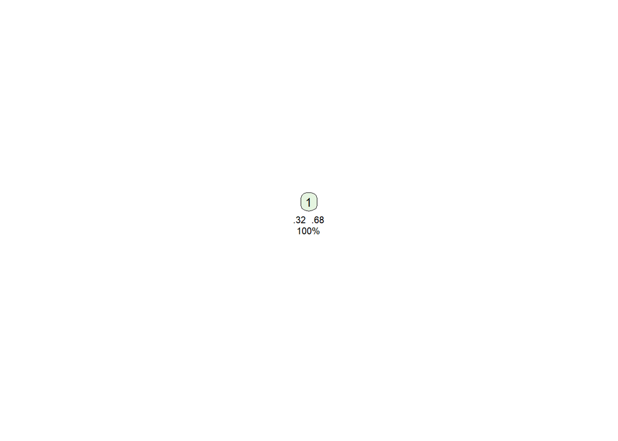

```r
# Fit the decision tree model with control parameters to avoid overfitting
model_tree1 <- rpart(
  b_stress_level ~ .,
  data = r_train,
  method = "class",
  control = rpart.control(minsplit = 20, minbucket = 10, cp = 0.01)
)

# Plot the decision tree with better visualization
rpart.plot(
  model_tree1,
  type = 3,          # Boxed plots
  extra = 104,       # Display class probabilities and percentages
  under = TRUE,      # Add class name under the boxes
  cex = 0.8          # Adjust text size
)
```

```r
# Evaluate the model on the training set
class_train_tree1 <- predict(model_tree1, type = "class")
cm_train_tree1 <- caret::confusionMatrix(
  class_train_tree1,
  r_train$b_stress_level,
  positive = "1"
)
print(cm_train_tree1)
```

```
## Confusion Matrix and Statistics
##
##           Reference
## Prediction    0    1
##          0    0    0
##          1  872 1819
##
##                Accuracy : 0.676
##                  95% CI : (0.6579, 0.6936)
##     No Information Rate : 0.676
##     P-Value [Acc > NIR] : 0.5092
##
##                   Kappa : 0
##
##  Mcnemar's Test P-Value : <2e-16
##
##             Sensitivity : 1.000
##             Specificity : 0.000
##          Pos Pred Value : 0.676
##          Neg Pred Value :   NaN
##              Prevalence : 0.676
##          Detection Rate : 0.676
##    Detection Prevalence : 1.000
##       Balanced Accuracy : 0.500
##
##        'Positive' Class : 1
##
```

```r
# Evaluate the model on the test set
class_test_tree1 <- predict(model_tree1, newdata = r_test, type = "class")
cm_test_tree1 <- caret::confusionMatrix(
  class_test_tree1,
  r_test$b_stress_level,
  positive = "1"
)
print(cm_test_tree1)
```

```
## Confusion Matrix and Statistics
##
##           Reference
## Prediction   0   1
##          0   0   0
##          1 218 454
##
##                Accuracy : 0.6756
##                  95% CI : (0.6387, 0.7109)
##     No Information Rate : 0.6756
##     P-Value [Acc > NIR] : 0.5183
##
##                   Kappa : 0
##
##  Mcnemar's Test P-Value : <2e-16
##
##             Sensitivity : 1.0000
##             Specificity : 0.0000
##          Pos Pred Value : 0.6756
##          Neg Pred Value :    NaN
##              Prevalence : 0.6756
##          Detection Rate : 0.6756
##    Detection Prevalence : 1.0000
##       Balanced Accuracy : 0.5000
##
##        'Positive' Class : 1
##
```

> Training set results: Accuracy = 67.60%, sensitivty = 100%, and specificity = 0% Test set results: Accuracy = 67.56%, sensitivty = 100%, and specificity = 0%

> We see that decision tree 1, which uses all the variables, performs the same as the null model in both the training and test sets.

# Decision Tree 2

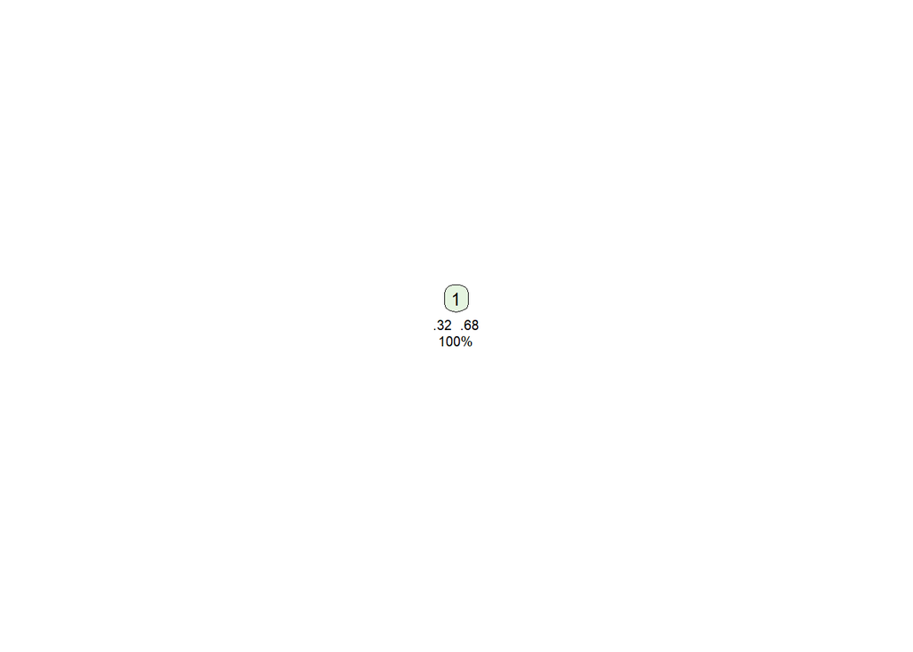

```r
# Fit the decision tree model with control parameters to avoid overfitting
model_tree2 <- rpart(
  b_stress_level ~ Social_Isolation_Rating +
                 Access_to_Mental_Health_Resources +
                 Satisfaction_with_Remote_Work +
                 Hours_Worked_Per_Week +
                 Work_Location + Job_Role,
  data = r_train,
  method = "class",
  control = rpart.control(minsplit = 20, minbucket = 10, cp = 0.01)
)

# Plot the decision tree with better visualization
rpart.plot(
  model_tree2,
  type = 3,          # Boxed plots
  extra = 104,       # Display class probabilities and percentages
  under = TRUE,      # Add class name under the boxes
  cex = 0.8          # Adjust text size
)
```

```r
# Evaluate the model on the training set
class_train_tree2 <- predict(model_tree2, type = "class")
cm_train_tree2 <- caret::confusionMatrix(
  class_train_tree2,
  r_train$b_stress_level,
  positive = "1"
)
print(cm_train_tree2)
```

```
## Confusion Matrix and Statistics
##
##           Reference
## Prediction    0    1
##          0    0    0
##          1  872 1819
##
##                Accuracy : 0.676
##                  95% CI : (0.6579, 0.6936)
##     No Information Rate : 0.676
##     P-Value [Acc > NIR] : 0.5092
##
##                   Kappa : 0
##
##  Mcnemar's Test P-Value : <2e-16
##
##             Sensitivity : 1.000
##             Specificity : 0.000
##          Pos Pred Value : 0.676
##          Neg Pred Value :   NaN
##              Prevalence : 0.676
##          Detection Rate : 0.676
##    Detection Prevalence : 1.000
##       Balanced Accuracy : 0.500
##
##        'Positive' Class : 1
##
```

```r
# Evaluate the model on the test set
class_test_tree2 <- predict(model_tree2, newdata = r_test, type = "class")
cm_test_tree2 <- caret::confusionMatrix(
  class_test_tree2,
  r_test$b_stress_level,
  positive = "1"
)
print(cm_test_tree2)
```

```
## Confusion Matrix and Statistics
##
##           Reference
## Prediction   0   1
##          0   0   0
##          1 218 454
##
##                Accuracy : 0.6756
##                  95% CI : (0.6387, 0.7109)
##     No Information Rate : 0.6756
##     P-Value [Acc > NIR] : 0.5183
##
##                   Kappa : 0
##
##  Mcnemar's Test P-Value : <2e-16
##
##             Sensitivity : 1.0000
##             Specificity : 0.0000
##          Pos Pred Value : 0.6756
##          Neg Pred Value :    NaN
##              Prevalence : 0.6756
##          Detection Rate : 0.6756
##    Detection Prevalence : 1.0000
##       Balanced Accuracy : 0.5000
##
##        'Positive' Class : 1
##
```

> Training set results: Accuracy = 67.60%, sensitivty = 100%, and specificity = 0% Test set results: Accuracy = 67.56%, sensitivty = 100%, and specificity = 0%

> We see that decision tree 2, which uses selected variables, performs the same as the null model in both the training and test sets.

# Random Forest Models

# Random Forest 1

```r
# Fit random forest model
rf1_train <- randomForest(b_stress_level ~ ., data = r_train, importance = TRUE)

# Training predictions
rf1_train_predict <- predict(rf1_train, type = "class")
rf1_cm <- confusionMatrix(rf1_train_predict, r_train$b_stress_level, positive = "1")
rf1_cm
```

```
## Confusion Matrix and Statistics
##
##           Reference
## Prediction    0    1
##          0    5   13
##          1  867 1806
##
##                Accuracy : 0.673
##                  95% CI : (0.6549, 0.6907)
##     No Information Rate : 0.676
##     P-Value [Acc > NIR] : 0.6377
##
##                   Kappa : -0.0019
##
##  Mcnemar's Test P-Value : <2e-16
##
##             Sensitivity : 0.992853
##             Specificity : 0.005734
##          Pos Pred Value : 0.675645
##          Neg Pred Value : 0.277778
##              Prevalence : 0.675957
##          Detection Rate : 0.671126
##    Detection Prevalence : 0.993311
##       Balanced Accuracy : 0.499294
##
##        'Positive' Class : 1
##
```

```r
# Test predictions
rf1_test_predict <- predict(rf1_train, newdata = r_test, type = "class")
rf1_test_cm <- confusionMatrix(rf1_test_predict, r_test$b_stress_level, positive = "1")
rf1_test_cm
```

```
## Confusion Matrix and Statistics
##
##           Reference
## Prediction   0   1
##          0   1   1
##          1 217 453
##
##                Accuracy : 0.6756
##                  95% CI : (0.6387, 0.7109)
##     No Information Rate : 0.6756
##     P-Value [Acc > NIR] : 0.5183
##
##                   Kappa : 0.0032
##
##  Mcnemar's Test P-Value : <2e-16
##
##             Sensitivity : 0.997797
##             Specificity : 0.004587
##          Pos Pred Value : 0.676119
##          Neg Pred Value : 0.500000
##              Prevalence : 0.675595
##          Detection Rate : 0.674107
##    Detection Prevalence : 0.997024
##       Balanced Accuracy : 0.501192
##
##        'Positive' Class : 1
##
```

> We see that random forest 1, which uses all the variables, performs similarly to the null model in both the training and test sets. There is a slight decrease in sensitivty for both sets and slight increase in specificity for the training set. These changes are not significant.

# Random Forest 2

```r
# Fit random forest model
rf2_train <- randomForest(b_stress_level ~ Social_Isolation_Rating +
                 Access_to_Mental_Health_Resources +
                 Satisfaction_with_Remote_Work +
                 Hours_Worked_Per_Week +
                 Work_Location + Job_Role,
                 data = r_train, importance = TRUE)

# Training predictions
rf2_train_predict <- predict(rf2_train, type = "class")
rf2_cm <- confusionMatrix(rf2_train_predict, r_train$b_stress_level, positive = "1")
rf2_cm
```

```
## Confusion Matrix and Statistics
##
##           Reference
## Prediction    0    1
##          0   15   40
##          1  857 1779
##
##                Accuracy : 0.6667
##                  95% CI : (0.6485, 0.6845)
##     No Information Rate : 0.676
##     P-Value [Acc > NIR] : 0.8532
##
##                   Kappa : -0.0063
##
##  Mcnemar's Test P-Value : <2e-16
##
##             Sensitivity : 0.9780
##             Specificity : 0.0172
##          Pos Pred Value : 0.6749
##          Neg Pred Value : 0.2727
##              Prevalence : 0.6760
##          Detection Rate : 0.6611
##    Detection Prevalence : 0.9796
##       Balanced Accuracy : 0.4976
##
##        'Positive' Class : 1
##
```

```r
# Test predictions
rf2_test_predict <- predict(rf2_train, newdata = r_test, type = "class")
rf2_test_cm <- confusionMatrix(rf2_test_predict, r_test$b_stress_level, positive = "1")
rf2_test_cm
```

```
## Confusion Matrix and Statistics
##
##           Reference
## Prediction   0   1
##          0   4   7
##          1 214 447
##
##                Accuracy : 0.6711
##                  95% CI : (0.6342, 0.7066)
##     No Information Rate : 0.6756
##     P-Value [Acc > NIR] : 0.6152
##
##                   Kappa : 0.0039
##
##  Mcnemar's Test P-Value : <2e-16
##
##             Sensitivity : 0.98458
##             Specificity : 0.01835
##          Pos Pred Value : 0.67625
##          Neg Pred Value : 0.36364
##              Prevalence : 0.67560
##          Detection Rate : 0.66518
##    Detection Prevalence : 0.98363
##       Balanced Accuracy : 0.50147
##
##        'Positive' Class : 1
##
```

> We see that random forest 2, which uses selected variables, again performs similarly to the null model in both the training and test sets. There is a slight decrease in sensitivty and slight increase in specificity in both sets. These results are better but not to a significant degree.

# Oversample the training set for better results

```r
library(ROSE)  # Random OverSampling
# Perform oversampling on the training set
r_train_balanced <- ROSE(b_stress_level ~ ., data = r_train, seed = 426)$data

# Check the new class distribution
table(r_train_balanced$b_stress_level)
```

```
##
##    1    0
## 1336 1355
```

```r
prop.table(table(r_train_balanced$b_stress_level))
```

```
##
##         1         0
## 0.4964697 0.5035303
```

```r
table(Hybrid_Remote_Data$b_stress_level)
```

```
##
##    0    1
## 1090 2273
```

```r
prop.table(table(Hybrid_Remote_Data$b_stress_level))
```

```
##
##         0         1
## 0.3241154 0.6758846
```

# Logistic Regression

# Logistic Regression 3

```r
# Reduced model with selected predictors
model_lr3 <- glm(b_stress_level ~ Social_Isolation_Rating +
                 Access_to_Mental_Health_Resources +
                 Satisfaction_with_Remote_Work +
                 Hours_Worked_Per_Week +
                 Work_Location + Job_Role,
                 data = r_train_balanced, family = binomial(link = "logit"))

# Training predictions
class_train_lr3 <- as.factor((predict(model_lr3, type = "response") > 0.5) * 1)
cm_train_lr3 <- confusionMatrix(class_train_lr3, r_train$b_stress_level, positive = "1")
cm_train_lr3
```

```
## Confusion Matrix and Statistics
##
##           Reference
## Prediction   0   1
##          0 398 842
##          1 474 977
##
##                Accuracy : 0.511
##                  95% CI : (0.4919, 0.53)
##     No Information Rate : 0.676
##     P-Value [Acc > NIR] : 1
##
##                   Kappa : -0.0058
##
##  Mcnemar's Test P-Value : <2e-16
##
##             Sensitivity : 0.5371
##             Specificity : 0.4564
##          Pos Pred Value : 0.6733
##          Neg Pred Value : 0.3210
##              Prevalence : 0.6760
##          Detection Rate : 0.3631
##    Detection Prevalence : 0.5392
##       Balanced Accuracy : 0.4968
##
##        'Positive' Class : 1
##
```

```r
# Generate predicted probabilities for the test set
balanced_probs_test <- predict(model_lr3, newdata = r_test, type = "response")

# Convert probabilities to classes using the threshold (0.5)
class_test_lr3 <- as.factor((balanced_probs_test > 0.5) * 1)

# Evaluate using confusion matrix
cm_test_lr3 <- caret::confusionMatrix(class_test_lr3, r_test$b_stress_level, positive = "1")
cm_test_lr3
```

```
## Confusion Matrix and Statistics
##
##           Reference
## Prediction   0   1
##          0  95 203
##          1 123 251
##
##                Accuracy : 0.5149
##                  95% CI : (0.4764, 0.5533)
##     No Information Rate : 0.6756
##     P-Value [Acc > NIR] : 1
##
##                   Kappa : -0.0104
##
##  Mcnemar's Test P-Value : 1.212e-05
##
##             Sensitivity : 0.5529
##             Specificity : 0.4358
##          Pos Pred Value : 0.6711
##          Neg Pred Value : 0.3188
##              Prevalence : 0.6756
##          Detection Rate : 0.3735
##    Detection Prevalence : 0.5565
##       Balanced Accuracy : 0.4943
##
##        'Positive' Class : 1
##
```

> Training set results: Accuracy = 51.10%, sensitivty = 53.71%, and specifcity = 45.64% Test set results: Accuracy = 51.49%, sensitivty = 55.29%, and specifcity = 43.58%

# Simple Decision Trees

# Decision Tree 3

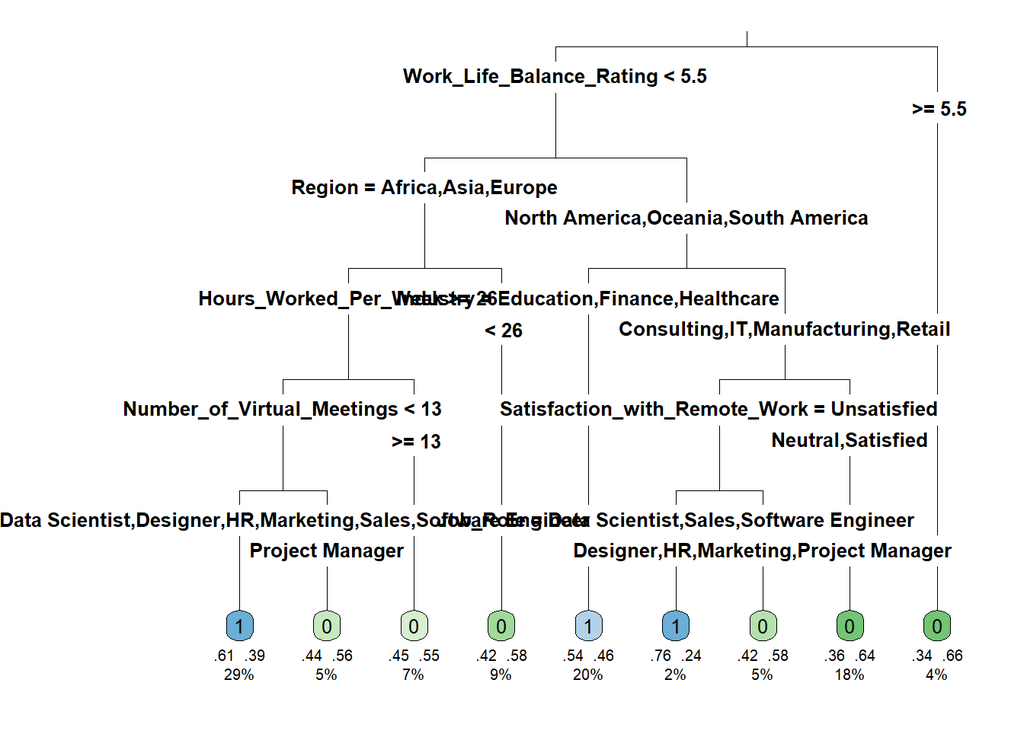

```r
# Fit the decision tree model with control parameters to avoid overfitting
model_tree3 <- rpart(
  b_stress_level ~ .,
  data = r_train_balanced,
  method = "class",
  control = rpart.control(minsplit = 20, minbucket = 10, cp = 0.01)
)

# Plot the decision tree with better visualization
rpart.plot(
  model_tree3,
  type = 3,          # Boxed plots
  extra = 104,       # Display class probabilities and percentages
  under = TRUE,      # Add class name under the boxes
  cex = 0.8          # Adjust text size
)
```

```r
# Evaluate the model on the training set
class_train_tree3 <- predict(model_tree3, type = "class")
cm_train_tree3 <- caret::confusionMatrix(
  class_train_tree3,
  r_train_balanced$b_stress_level,
  positive = "1"
)
print(cm_train_tree3)
```

```
## Confusion Matrix and Statistics
##
##           Reference
## Prediction   1   0
##          1 822 570
##          0 514 785
##
##                Accuracy : 0.5972
##                  95% CI : (0.5784, 0.6158)
##     No Information Rate : 0.5035
##     P-Value [Acc > NIR] : < 2e-16
##
##                   Kappa : 0.1945
##
##  Mcnemar's Test P-Value : 0.09482
##
##             Sensitivity : 0.6153
##             Specificity : 0.5793
##          Pos Pred Value : 0.5905
##          Neg Pred Value : 0.6043
##              Prevalence : 0.4965
##          Detection Rate : 0.3055
##    Detection Prevalence : 0.5173
##       Balanced Accuracy : 0.5973
##
##        'Positive' Class : 1
##
```

```r
# Evaluate the model on the test set
class_test_tree3 <- predict(model_tree3, newdata = r_test, type = "class")
cm_test_tree3 <- caret::confusionMatrix(
  class_test_tree3,
  r_test$b_stress_level,
  positive = "1"
)
print(cm_test_tree3)
```

```
## Confusion Matrix and Statistics
##
##           Reference
## Prediction   0   1
##          0  97 197
##          1 121 257
##
##                Accuracy : 0.5268
##                  95% CI : (0.4882, 0.5651)
##     No Information Rate : 0.6756
##     P-Value [Acc > NIR] : 1
##
##                   Kappa : 0.0101
##
##  Mcnemar's Test P-Value : 2.602e-05
##
##             Sensitivity : 0.5661
##             Specificity : 0.4450
##          Pos Pred Value : 0.6799
##          Neg Pred Value : 0.3299
##              Prevalence : 0.6756
##          Detection Rate : 0.3824
##    Detection Prevalence : 0.5625
##       Balanced Accuracy : 0.5055
##
##        'Positive' Class : 1
##
```

> Training set results: Accuracy = 59.72%, sensitivty = 61.53%, and specifcity = 57.93% Test set results: Accuracy = 52.68%, sensitivty = 56.61%, and specifcity = 44.50%

# Decision Tree 4

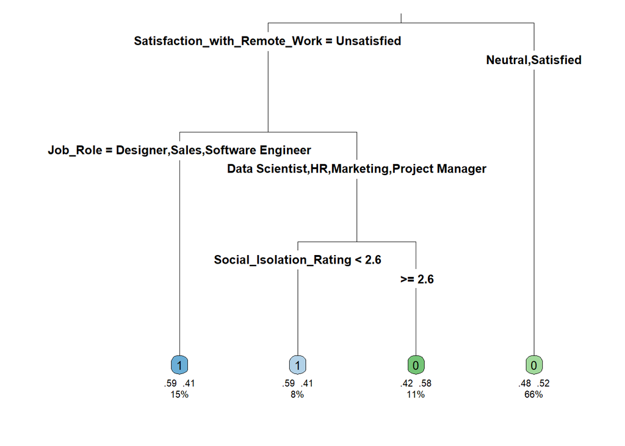

```r
# Fit the decision tree model with control parameters to avoid overfitting
model_tree4 <- rpart(
  b_stress_level ~ Social_Isolation_Rating +
                 Access_to_Mental_Health_Resources +
                 Satisfaction_with_Remote_Work +
                 Hours_Worked_Per_Week +
                 Work_Location + Job_Role,
  data = r_train_balanced,
  method = "class",
  control = rpart.control(minsplit = 20, minbucket = 10, cp = 0.01)
)

# Plot the decision tree with better visualization
rpart.plot(
  model_tree4,
  type = 3,          # Boxed plots
  extra = 104,       # Display class probabilities and percentages
  under = TRUE,      # Add class name under the boxes
  cex = 0.8          # Adjust text size
)
```

```r
# Evaluate the model on the training set
class_train_tree4 <- predict(model_tree4, type = "class")
cm_train_tree4 <- caret::confusionMatrix(
  class_train_tree4,
  r_train_balanced$b_stress_level,
  positive = "1"
)
print(cm_train_tree4)
```

```
## Confusion Matrix and Statistics
##
##           Reference
## Prediction    1    0
##          1  367  253
##          0  969 1102
##
##                Accuracy : 0.5459
##                  95% CI : (0.5269, 0.5648)
##     No Information Rate : 0.5035
##     P-Value [Acc > NIR] : 5.953e-06
##
##                   Kappa : 0.0883
##
##  Mcnemar's Test P-Value : < 2.2e-16
##
##             Sensitivity : 0.2747
##             Specificity : 0.8133
##          Pos Pred Value : 0.5919
##          Neg Pred Value : 0.5321
##              Prevalence : 0.4965
##          Detection Rate : 0.1364
##    Detection Prevalence : 0.2304
##       Balanced Accuracy : 0.5440
##
##        'Positive' Class : 1
##
```

```r
# Evaluate the model on the test set
class_test_tree4 <- predict(model_tree4, newdata = r_test, type = "class")
cm_test_tree4 <- caret::confusionMatrix(
  class_test_tree4,
  r_test$b_stress_level,
  positive = "1"
)
print(cm_test_tree4)
```

```
## Confusion Matrix and Statistics
##
##           Reference
## Prediction   0   1
##          0 158 348
##          1  60 106
##
##                Accuracy : 0.3929
##                  95% CI : (0.3557, 0.4309)
##     No Information Rate : 0.6756
##     P-Value [Acc > NIR] : 1
##
##                   Kappa : -0.0311
##
##  Mcnemar's Test P-Value : <2e-16
##
##             Sensitivity : 0.2335
##             Specificity : 0.7248
##          Pos Pred Value : 0.6386
##          Neg Pred Value : 0.3123
##              Prevalence : 0.6756
##          Detection Rate : 0.1577
##    Detection Prevalence : 0.2470
##       Balanced Accuracy : 0.4791
##
##        'Positive' Class : 1
##
```

> Training set results: Accuracy = 54.59%, sensitivty = 27.47%, and specifcity = 81.33% Test set results: Accuracy = 39.29%, sensitivty = 23.35%, and specifcity = 72.48%

> With oversampling of the training data we see that decision tree 4, which uses selected variables, performs worse than decision tree 3 where there was a significant increase in specificity but at the cost of sensitivity. There is a significant drop in accuracy from the training to the test.

# Random Forest Models

# Random Forest 3

```r
# Fit random forest model
rf3_train <- randomForest(b_stress_level ~ ., data = r_train_balanced, importance = TRUE)

# Training predictions
rf3_train_predict <- predict(rf3_train, type = "class")
rf3_cm <- confusionMatrix(rf3_train_predict, r_train_balanced$b_stress_level, positive = "1")
rf3_cm
```

```
## Confusion Matrix and Statistics
##
##           Reference
## Prediction    1    0
##          1 1030  246
##          0  306 1109
##
##                Accuracy : 0.7949
##                  95% CI : (0.7791, 0.81)
##     No Information Rate : 0.5035
##     P-Value [Acc > NIR] : < 2e-16
##
##                   Kappa : 0.5896
##
##  Mcnemar's Test P-Value : 0.01203
##
##             Sensitivity : 0.7710
##             Specificity : 0.8185
##          Pos Pred Value : 0.8072
##          Neg Pred Value : 0.7837
##              Prevalence : 0.4965
##          Detection Rate : 0.3828
##    Detection Prevalence : 0.4742
##       Balanced Accuracy : 0.7947
##
##        'Positive' Class : 1
##
```

```r
# Test predictions
rf3_test_predict <- predict(rf3_train, newdata = r_test, type = "class")
rf3_test_cm <- confusionMatrix(rf3_test_predict, r_test$b_stress_level, positive = "1")
rf3_test_cm
```

```
## Confusion Matrix and Statistics
##
##           Reference
## Prediction   0   1
##          0  70 144
##          1 148 310
##
##                Accuracy : 0.5655
##                  95% CI : (0.527, 0.6033)
##     No Information Rate : 0.6756
##     P-Value [Acc > NIR] : 1.0000
##
##                   Kappa : 0.0039
##
##  Mcnemar's Test P-Value : 0.8606
##
##             Sensitivity : 0.6828
##             Specificity : 0.3211
##          Pos Pred Value : 0.6769
##          Neg Pred Value : 0.3271
##              Prevalence : 0.6756
##          Detection Rate : 0.4613
##    Detection Prevalence : 0.6815
##       Balanced Accuracy : 0.5020
##
##        'Positive' Class : 1
##
```

> With oversampling of the training data we see that random forest 3, which uses all the variables, results are also a signifcant improvment from the null and non-oversampled models. There is a concerning drop in accuracy and specificity for this model.

# Random Forest 4

```r
# Fit random forest model
rf4_train <- randomForest(b_stress_level ~ Social_Isolation_Rating +
                 Access_to_Mental_Health_Resources +
                 Satisfaction_with_Remote_Work +
                 Hours_Worked_Per_Week +
                 Work_Location + Job_Role,
                 data = r_train_balanced, importance = TRUE)

# Training predictions
rf4_train_predict <- predict(rf4_train, type = "class")
rf4_cm <- confusionMatrix(rf4_train_predict, r_train_balanced$b_stress_level, positive = "1")
rf4_cm
```

```
## Confusion Matrix and Statistics
##
##           Reference
## Prediction   1   0
##          1 821 555
##          0 515 800
##
##                Accuracy : 0.6024
##                  95% CI : (0.5836, 0.6209)
##     No Information Rate : 0.5035
##     P-Value [Acc > NIR] : <2e-16
##
##                   Kappa : 0.2049
##
##  Mcnemar's Test P-Value : 0.2332
##
##             Sensitivity : 0.6145
##             Specificity : 0.5904
##          Pos Pred Value : 0.5967
##          Neg Pred Value : 0.6084
##              Prevalence : 0.4965
##          Detection Rate : 0.3051
##    Detection Prevalence : 0.5113
##       Balanced Accuracy : 0.6025
##
##        'Positive' Class : 1
##
```

```r
# Test predictions
rf4_test_predict <- predict(rf4_train, newdata = r_test, type = "class")
rf4_test_cm <- confusionMatrix(rf4_test_predict, r_test$b_stress_level, positive = "1")
rf4_test_cm
```

```
## Confusion Matrix and Statistics
##
##           Reference
## Prediction   0   1
##          0 104 205
##          1 114 249
##
##                Accuracy : 0.5253
##                  95% CI : (0.4868, 0.5636)
##     No Information Rate : 0.6756
##     P-Value [Acc > NIR] : 1
##
##                   Kappa : 0.023
##
##  Mcnemar's Test P-Value : 4.679e-07
##
##             Sensitivity : 0.5485
##             Specificity : 0.4771
##          Pos Pred Value : 0.6860
##          Neg Pred Value : 0.3366
##              Prevalence : 0.6756
##          Detection Rate : 0.3705
##    Detection Prevalence : 0.5402
##       Balanced Accuracy : 0.5128
##
##        'Positive' Class : 1
##
```

> With oversampling of the training data we see that random forest 4, which uses selected variables, performs better than random forest 3 as there are no significant drops in accuracy, sensitivity, or specificity. The overall results of this model is still lackluster as each remain close to 50%.

## Key Findings

> Iterations of the models: logistic regression, simple decision tree, and random forest were created; however, the results (accuracy, sensitivty, and specificity) were ambiguous. Many models, for example, had their test set perform better than their training set which could imply numerous concerns, such as overfitting of the training set, the training and test set are not diverse enough, etc.

> We consistently varied different elements of the models to observe if there were any key differences, such as the threshold for the logistic regression, the different input variables, and comparing results.

> We discovered that performing oversampling on the training data helped in attaining more interpretable results. Through oversampling, we found that our best model for predicting b_stress_levels would be logistic regression 3, decision tree 3, or random forest 4. None of these models are not ideal and we can conclude that the Stress_Levels (became b_stress_levels) is not a good predictor for finding out in assessing mental health of employees that work remotely.

## Challenges

> Although the data has no missing values in any of the variables, the results in our corresponding predictive models for Stress_Levels has not provided any distinguishable outputs.

> Found that oversampling on the training data helped differentiate results from the null model and models were made to observe between non-oversampled vs. oversampled models.

## Personal Learning

> Not all datasets and choosing an outcome variable will necesarily derive positive results as many models with different input variables were tested, but the ambiguous results remained. This leads us to conclude that the Stress_Levels variable, in which we changed to become a binary variable: b_stress_levels, is not a good target variable to predict mental health trends in terms of stress levels where we wanted to see if working remotely and/or hybrid resulted in lower stress levels.

> In class, we learned and utilized the 80% and 20% parition of data; however, it is not the only effective parition and so in this project we tested another partition of 75% and 25% to observe if there were more accurate results. We could further test this with other partitions, such as 70% and 30% or 90% and 10%.

> We learned the critical importance of consistently checking and testing our code to ensure both functionality and accuracy. It became clear that just because code executes without errors does not necessarily mean the results are valid or meaningful. For instance, when we compared the performance of our logistic regression model on the train set to the null model, they yielded identical results. This made us carefully review our code and methods. This is because having such an outcome could have indicated potential issues — whether it was in our data preparation, feature selection, or model implementation. This experience emphasized the importance of interpreting results thoughtfully and verifying that the model is leveraging predictive features effectively, rather than simply mimicking the baseline.